# Percepton and Shallow Neural Network

Shyla C. Solis

11/24/2020

## Introduction

An online rental video company is interested in creating a model to make movie recommendations to one of its customers, Ms. X. As a consultant to this company, you are provided with the history of the movies that she accepted or rejected to watch. She makes her selections solely based on the movie genre and critic ratings. The data is in movieData.csv

## Read & Examine the Data

The original data:

```
##    LevelOfViolence CriticsRating Watched
## 1                1           1.2      -1
## 2                1           3.5       1
## 3                1           4.2       1
## 4                2           3.9       1
## 5                2           2.8      -1
## 6                3           3.0      -1
## 7                5           4.5      -1
## 8                4           1.8      -1
## 9                1           2.1      -1
## 10               3           4.8       1
## 11               5           4.9       1
## 12               3           1.5      -1
## 13               3           2.6      -1
```

We observe, there are 13 rows with 3 features. The feature, “LevelOfViolence” is a rank, this variable is an interval measurement. The feature, “CriticsRating”, sounds like a rating, hence the given name for the variable, however, since the variable contains a zero point it is a ratio measurement.The last variable, “Watched”, is a nominal measurement since it’s identifying a type rather than amounts of something.

Let’s learn more about the data we will be working with:

```
## 'data.frame':    13 obs. of  3 variables:
##  $ LevelOfViolence: int  1 1 1 2 2 3 5 4 1 3 ...
##  $ CriticsRating  : num  1.2 3.5 4.2 3.9 2.8 3 4.5 1.8 2.1 4.8 ...
##  $ Watched        : int  -1 1 1 1 -1 -1 -1 -1 -1 1 ...
```

Notice, the stored elements in column, “Watched” are integers. We will need to change them to factors instead (prepare to work with ggplot).

```
## 'data.frame':    13 obs. of  3 variables:
##  $ LevelOfViolence: int  1 1 1 2 2 3 5 4 1 3 ...
##  $ CriticsRating  : num  1.2 3.5 4.2 3.9 2.8 3 4.5 1.8 2.1 4.8 ...
##  $ Watched        : Factor w/ 2 levels "-1","1": 1 2 2 2 1 1 1 1 1 2 ...
```

Let’s now visualize the customers history of recommendations by plotting Ms. X’s recorded metrics for movies she accepted or rejected. We will do this by plotting “LevelOfViolence” vs. “CriticRating”.

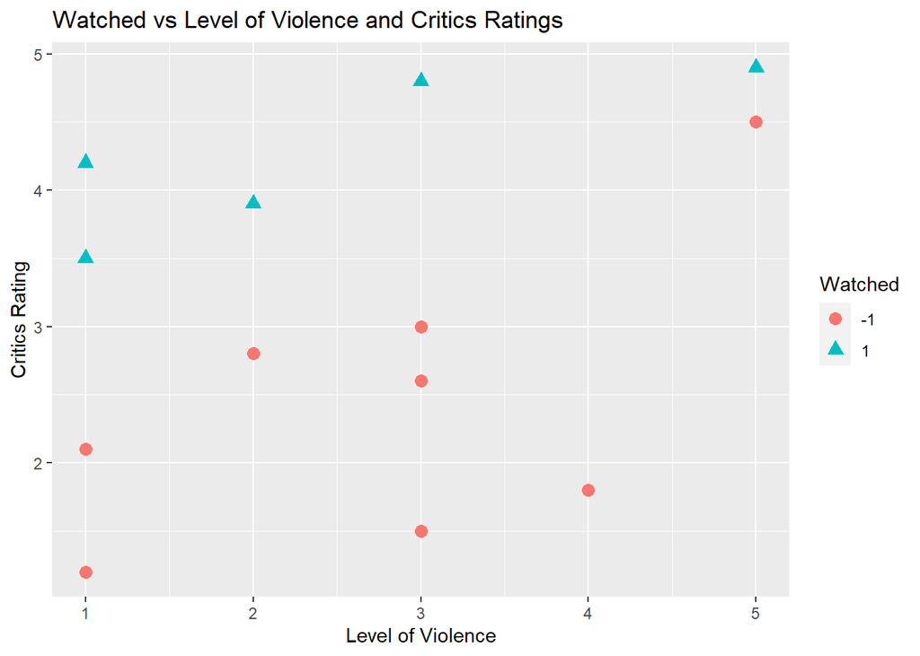

After observing the data, we see the data is linearly separable.The Perceptron (1957) by Rosenblatt is an algorithm for supervised learning of binary classifiers.It makes the assumption that there must be a hyper plane that separates one class from the other. “There exists a hyper plane such that all the points from one class lay on one side of the hyper plane, while all the points from the other class lay on the other side of the hyper plane”. https://www.youtube.com/watch?v=BbYV8UfMJSA&t=546s

```
##    ones LevelOfViolence CriticsRating  y
## 1     1               1           1.2 -1
## 2     1               1           3.5  1
## 3     1               1           4.2  1
## 4     1               2           3.9  1
## 5     1               2           2.8 -1
## 6     1               3           3.0 -1
## 7     1               5           4.5 -1
## 8     1               4           1.8 -1
## 9     1               1           2.1 -1
## 10    1               3           4.8  1
## 11    1               5           4.9  1
## 12    1               3           1.5 -1
## 13    1               3           2.6 -1
```

## Train a perceptron

I will use the Perceptron Learning Algorithm (PLA), which will create a linear boundary decision that will help the company to make future recommendations to Ms. X and report the model and the number of iterations it took for the weights to converge.

```
## [1] "The number of iterations is: 27"
```

Therefore, the finite number of times the W vector was updated is described by the number of iterations it took to converge. At this point, all vectors have been classified correctly.

```
## [1] "This is the final W: where w0= -19.7124224798754 w1= -8.21169486455619 and w2= 12.8089769218117"
```

```
## [1] "Here is the model"
```

```
## [1] "y=0.6410891x+1.538954"
```

For more details and intuition on the perceptron, use: http://hagan.okstate.edu/4_Perceptron.pdf AND https://page.mi.fu-berlin.de/rojas/neural/chapter/K4.pdf